# Understanding Voter Turn Out Behavior: Insights for Non-Partisan Engagement

April 2024

#### Data Selection

To begin the process of developing a model to forecast individual voting turnout behavior, appropriate data sets were identified. The Cooperative Election Study (CES) provided comprehensive information, with both a cumulative dataset spanning from 2006 to 2022, consisting of standardized variables across the years the survey was administerd, and year-specific datasets which expanded on information not included in the cumulative file. Given its pre-organized structure and inclusion of cross-year data, this cumulative dataset served as a starting point for addressing the prediction problem while the year-specific data sets built upon it. The data was narrowed down to include only information from 2020 to 2022 to ensure relevance and recency. Rows lacking labeled data for the outcome variable were filtered out, but this only led to a 4% decrease in the dataset, necessary for the supervised learning approach.

#### Outcome Variable Granularity and Imbalance

The outcome variable initially considered was vote intention, yet its granularity, with six levels, exceeded the information necessary for this prediction task. Figure 1 displays the levels for vote intention as well as their propotion in the data. Moreover, intending to vote does not always equate to actual voting turnout behavior. Thus, a new outcome variable was constructed by merging `vv_turnout_gvm`, which provides validated voting information, with `intent_turnout_self` if validated voting information was not available. This approach resulted in a binary outcome variable reflecting more accurate turnout behavior, and a more balanced outcome variable. Analysis revealed that a majority of those who responded “Probably” or “Undecided” with their intent to vote actually ended up not voting and some people who reported they already voted early didn’t vote at all, indicating a disparity between intention and action. Consequently, the refined outcome variable comprised two levels, addressing both granularity and imbalance concerns which is shown in Figure 2.

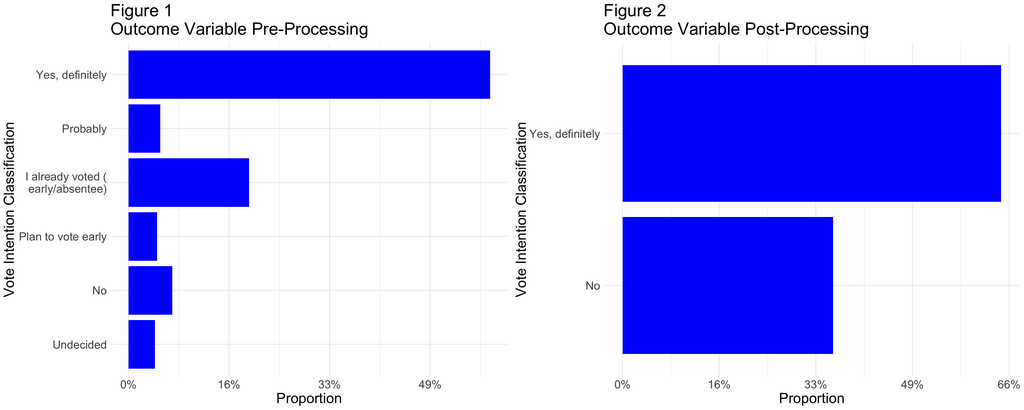

#### Feature Selection and Handling Missing Data

Initially, a wide array of 180 columns were included in the dataset, recognizing the potential predictive value of diverse features. Basic demographic data like age, family income and marital status were included along with a wide range of individuals’ opinions on political issues like COVID, police reform and the economy. Among these, 12 demographic columns contained missing data, each with less than 1% of missing rows. To address this, I employed MissForest for imputation. Figure 3 displays density plots comparing the distribution of imputed variables with the original values, with the column names represented on the x-axis. Given the similarity in the distribution of densities and after comparing the suitability of this imputation with that produced from the [MICE](https://cran.r-project.org/web/packages/mice/mice.pdf) package, missForest proved to be the best option.

For missing values in political opinion columns, they were recoded as 99. Considering these values mainly resulted from skipped questions due to survey logic, in which the question was deemed irrelevant to the individual, it was important to document that these questions were missing instead of imputing them. In some cases the question was skipped intentionally by the indiividual but the CEC docuented this occurence within the data.

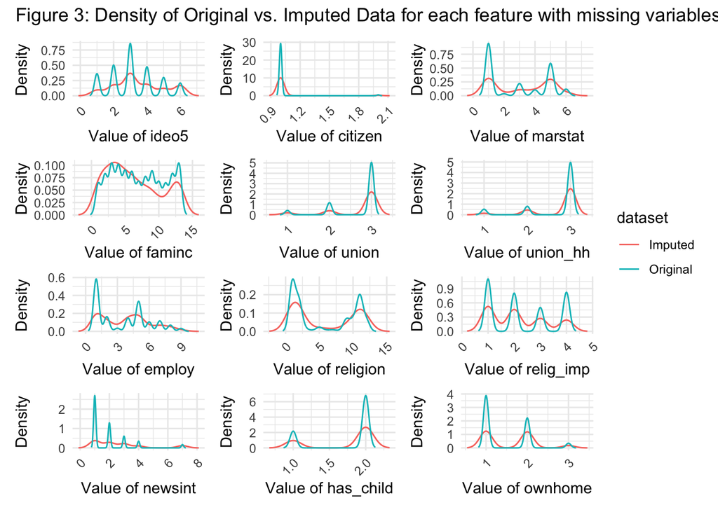

#### Variables of Importance

Variable importance analysis identified registration status as the most influential predictor of voting behavior. This underscores the potential effectiveness of voter registration campaigns in increasing voter turnout. Since citizenship status is a requirement of being able to vote, its inclusion in voter turnout behavior also makes sense. Additionally, engagement with media (`media_2`) as well as individuals’ opinions on the government’s handling of the pandemic economically and in terms of public health (`covid_` questions) emerged as important predictors. Interestingly, healthcare and economic issues were also the most important issues to voters in 2020 according to the [Pew Research Center](https://www.pewresearch.org/politics/2020/08/13/important-issues-in-the-2020-election/). Given that voter concerns change over time, future iterations of this model may include new political opinion questions that the CES asks to ensure its capturing the most important political issues to voters which may help predict voter turn out.

To find the columns that correspond with these variables please see the function `rename_columns_based_on_start` which identifies the column name provided by the CES with the features presented below. The columns were renamed for easier interprebility while data processing.

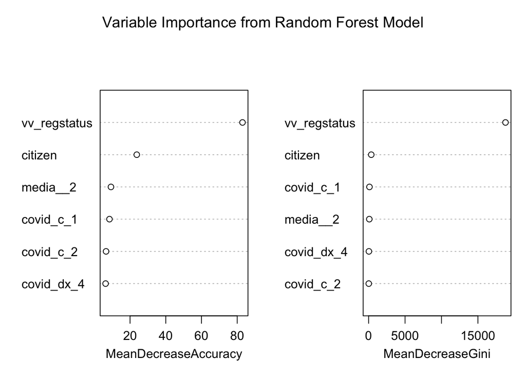

## Appendix: All code in this assignment

```r
knitr::opts_chunk$set(echo = FALSE, warning = FALSE, message = FALSE)

#load packages
library("lightgbm")
library("missForest")
library("ggplot2")
library("dplyr")
library("haven")
library("glmnet")
library("tidyr")
library("fixr")
library("smotefamily")
library("caret")
library("RSQLite")
library("randomForest")
library("patchwork")
# Function to remove prefixes from column names
remove_prefixes <- function(df) {

  # Rename columns by removing prefixes (including underscores)
  new_names <- gsub("^.*?_", "", names(df))

  # Assign the new names back to the df
  names(df) <- new_names

  return(df)
}

# Function to rename columns based on starting patterns
rename_columns_based_on_start <- function(df) {
  df <- df %>%
    rename_with(~ gsub("^332", "abortion_", .x), starts_with("332")) %>%
    rename_with(~ gsub("^323", "abortion_", .x), starts_with("323")) %>%
    rename_with(~ gsub("^333", "climate_change_", .x), starts_with("333")) %>%
    rename_with(~ gsub("^324", "climate_change_", .x), starts_with("324")) %>%
    rename_with(~ gsub("^309", "covid_", .x), starts_with("309")) %>%
    rename_with(~ gsub("^305", "covid_", .x), starts_with("305")) %>%
    rename_with(~ gsub("^330", "gun_control_", .x), starts_with("330")) %>%
    rename_with(~ gsub("^321", "gun_control_", .x), starts_with("321")) %>%
    rename_with(~ gsub("^327", "healthcare_", .x), starts_with("327")) %>%
    rename_with(~ gsub("^320", "healthcare_", .x), starts_with("320")) %>%
    rename_with(~ gsub("^331", "immigration_", .x), starts_with("331")) %>%
    rename_with(~ gsub("^322", "immigration_", .x), starts_with("322")) %>%
    rename_with(~ gsub("^300", "media_", .x), starts_with("300")) %>%
    rename_with(~ gsub("^334", "police_", .x), starts_with("334")) %>%
    rename_with(~ gsub("^440", "racial_resent_", .x), starts_with("440"))

  return(df)
}

# Function to make 2 df's have the same columns
fill_missing_columns <- function(df1, df2) {

  # Get missing columns in df1 compared to df2
  missing_in_df1 <- setdiff(names(df2), names(df1))

  # Add missing columns to df1 and fill with NA
  if (length(missing_in_df1) > 0) {
    df1[, missing_in_df1] <- NA
  }

  # Get missing columns in df2 compared to df1
  missing_in_df2 <- setdiff(names(df1), names(df2))

  # Add missing columns to df2 and fill with NA
  if (length(missing_in_df2) > 0) {
    df2[, missing_in_df2] <- NA
  }

  return(list(df1, df2))
}

# Function to compute variable importance for a given model object
varImp <- function(object, lambda = NULL, ...) {

  # Predict coefficients for the specified lambda value
  beta <- predict(object, s = lambda, type = "coef")

  # Check if the coefficients are in a list format (e.g., for models with multiple classes)
  if (is.list(beta)) {

    # If coefficients are in a list format, extract the first column of each and combine them
    out <- do.call("cbind", lapply(beta, function(x) x[,1]))

    # Convert the result into a data frame
    out <- as.data.frame(out, stringsAsFactors = TRUE)
  } else {

    # If coefficients are not in a list format use the first column
    out <- data.frame(Overall = beta[,1])
  }

  # Remove the "(Intercept)" row from the output
  out <- abs(out[rownames(out) != "(Intercept)", , drop = FALSE])

  # Return the variable importance
  return(out)
}

# Find the best parameters for a lightgbm model
random_search_lgbm <- function(parameter_values_fixed,
                              n_draws,
                              training_dataset,
                              seed_int) {

  ## 1. Status update

  print("Starting the random hyper-parameter search ..")

  ## 2. Create a data frame to store the outcomes

  search_output <- data.frame(learning_rate = numeric(),
                             num_leaves = numeric(),
                             max_depth = numeric(),
                             feature_fraction = numeric(),
                             bagging_fraction = numeric(),
                             is_unbalance = logical(),
                             score = numeric(),
                             lambda_l1 = numeric(),
                             lambda_l2 = numeric(),
                             min_split_gain = numeric(),
                             subsample = numeric(),
                             colsample_bytree = numeric(),
                             max_drop = numeric())


  ## 3. Training the models

  # Set seed
  set.seed(seed_int)

  # Iterations
  for (ii in 1:n_draws) {

    # Picking a random point in the hyper-parameter space and storing it
    search_output[ii, "learning_rate"] <- exp(runif(1, min = -4.6, max = -0.7))
    search_output[ii, "num_leaves"] <- round(runif(1, min = 2, max = 200))
    search_output[ii, "max_depth"] <- round(runif(1, min = 1, max = 30))
    search_output[ii, "feature_fraction"] <- runif(1, min = .6, max = 1) #updated from previous runs
    search_output[ii, "bagging_fraction"] <- runif(1, min = 0, max = 1)
    search_output[ii, "is_unbalance"] <- sample(c(TRUE, FALSE), 1)
    search_output[ii, "lambda_l1"] <- exp(runif(1, min = -6, max = 2))
    search_output[ii, "lambda_l2"] <- exp(runif(1, min = -6, max = 2))
    search_output[ii, "min_split_gain"] <- runif(1, min = 0.0, max = 0.1)
    search_output[ii, "subsample"] <- runif(1, min = 0.7, max = 1)
    search_output[ii, "colsample_bytree"] <- runif(1, min = 0.5, max = 1)
    search_output[ii, "max_drop"] <- round(runif(1, min = 40, max = 50))

    # Transforming the parameter values into a list
    parameter_values_variable <- as.list(search_output[ii, !(colnames(search_output) %in% "score")])

    # Combining with fixed parameters and seed
    current_params <- c(parameter_values_fixed, parameter_values_variable, list(seed = seed_int))

    # Cross validation
    sink(tempfile()) # prevents printouts as verbose=-1
    current_cv <- lgb.cv(
      params = current_params,
      data = training_dataset,
      nrounds = 500,
      nfold = 5,
      verbose = -1
    )
    sink()
```

```r
    # Storing the score in the final boosting round
    search_output[ii,"score"] <- current_cv$record_evals$valid$auc$eval[[500]]

    # Status update
    if (ii %% 50 == 0) {

      print(sprintf("%s/%s models trained.", ii, n_draws))

    }

  }

  # Sorting to obtain parameter combination with the best score first
  search_output <- search_output[order(-search_output$score),]

  return(search_output)

}
# Establish directory to database
database = 'database/training_data.db'

# Read in data
cumulative <- readRDS("cumulative_2006-2022.rds")

df_2022 <- read_dta("2022_data/CCES22_Common_OUTPUT_vv_topost.dta")
df_2021 <- read_dta("2021_data/CCES21_Common_OUTPUT.dta")
df_2020 <- read_dta("2020_data/CES20_Common_OUTPUT_vv.dta")

# Filter to only 2020 data and after
cumulative_filtered <- cumulative %>%

  # Filter to rows that have labeled data for relevant years
  filter((!is.na(intent_turnout_self) & !is.na(vv_turnout_gvm)) & year >= 2020)

# Get outcome variables
outcome_vars <- cumulative_filtered %>%
  select(case_id, vv_turnout_gvm, intent_turnout_self)

# Get predictor variables
predictors <- cumulative_filtered %>%

  # Select columns with relevant demographic and political opinion data
  select(case_id, pid3, ideo5, gender, age, race,
         citizen, educ, marstat, faminc, union, union_hh, employ,
         no_healthins, has_child, ownhome, no_milstat, religion, relig_imp,
         newsint, approval_pres, approval_gov, economy_retro, vv_regstatus) %>%

  # Change all factor data to numeric
  mutate_if(is.factor, as.numeric) %>%

  #replace all spaces with an underscore
  fix_col_spaces(.)

# Set levels for outcome variable
vote_levels <- c("Yes, definitely", "No" )

# Use the verified voting data, otherwise, use the intent data
outcome_vars_processed <- outcome_vars %>%

  mutate(will_vote = case_when(
    vv_turnout_gvm == "Voted" ~ "Yes, definitely", #has a record of voting
    vv_turnout_gvm %in% "No Record of Voting" ~ "No", #has no record of voting
    intent_turnout_self == "I already voted (early or absentee)" ~ "Yes, definitely",
    intent_turnout_self == "Plan to vote early" ~ "Yes, definitely",
    intent_turnout_self == "Probably" ~ "Probably/Undecided",
    intent_turnout_self == "Undecided" ~ "Probably/Undecided",
    is.na(vv_turnout_gvm) ~ as.character(intent_turnout_self),
    TRUE ~ as.character(intent_turnout_self)
  )) %>%

  # Convert outcome variable to a factor with specified levels
  mutate(will_vote = factor(will_vote, levels = vote_levels)) %>%

  select(case_id, will_vote)
library(cowplot)
# Calculate the number of rows
total_count <- nrow(outcome_vars)

# Plot classes in the intent_turnout_self col
p1 <- ggplot(outcome_vars, aes(y = reorder(intent_turnout_self, -as.numeric(intent_turnout_self)))) +
  geom_bar(position = "dodge", fill = "blue") +
  scale_x_continuous(labels = function(x) scales::percent(as.numeric(x) / total_count)) +
  labs(title = "Figure 1 \nOutcome Variable Pre-Processing", y = "Vote Intention Classification", x = "Proportion") +
  theme_minimal() +
  theme(
    axis.text = element_text(size = 16),   # Adjust the size of axis text
    axis.title = element_text(size = 20),  # Adjust the size of axis titles
    plot.title = element_text(size = 24)   # Adjust the size of the plot title
  )

p1 <- p1 + scale_y_discrete(labels = function(x) gsub("early or absentee", "\nearly/absentee", x))

# Plot the will_vote column
p2 <- ggplot(outcome_vars_processed, aes(y = reorder(will_vote, -as.numeric(will_vote)))) +
  geom_bar(position = "dodge", fill = "blue") +
  scale_x_continuous(labels = function(x) scales::percent(as.numeric(x) / total_count)) +
  labs(title = "Figure 2 \nOutcome Variable Post-Processing", y = "Vote Intention Classification", x = "Proportion") +
  theme_minimal() +
  theme(
    axis.text = element_text(size = 16),   # Adjust the size of axis text
    axis.title = element_text(size = 20),  # Adjust the size of axis titles
    plot.title = element_text(size = 24)   # Adjust the size of the plot title
  )

plot_grid(p1, p2, ncol = 2, hjust = -15, vjust = 15)

# Keep cols on abortion, climate change, covid, Economy, gun control, healthcare,
#immigration, media, police and Racial Resentment/Sexism
df_2022_filtered <- df_2022 %>%
  select(caseid, matches(paste0("^CC22_332|^CC22_333|^CC22_309",
  "|^CC22_330|^CC22_327|^CC22_331|^CC22_300|^CC22_334|^CC22_440")) )

#no police or racial resentment data for 2021
df_2021_filtered <- df_2021 %>%
  select(caseid, matches(paste0("^CC21_323|^CC21_324|^CC21_305",
  "|^CC21_321|^CC21_320|^CC21_322|^CC21_300")) )

df_2020_filtered <- df_2020 %>%
  select(caseid, matches(paste0("^CC20_332|^CC20_333|^CC20_309",
  "|^CC20_330|^CC20_327|^CC20_331|^CC20_300|^CC20_334|^CC20_440")) )

# Remove pre-fixes for each df
df_2022_prefix <- remove_prefixes(df_2022_filtered)
df_2021_prefix <- remove_prefixes(df_2021_filtered)
df_2020_prefix <- remove_prefixes(df_2020_filtered)

# Apply more descriptive names to columns
df_2022_cols <- rename_columns_based_on_start(df_2022_prefix)
df_2021_cols <- rename_columns_based_on_start(df_2021_prefix)
df_2020_cols <- rename_columns_based_on_start(df_2020_prefix)

# Ensure consistency between columns of datasets from 2022 and 2021
filled_dfs_2022_2021 <- fill_missing_columns(df_2022_cols, df_2021_cols)

# Concatenate datasets from 2022 and 2021
df_2022_2021 <- rbind(filled_dfs_2022_2021[[1]], filled_dfs_2022_2021[[2]])

# Ensure consistency between columns of combined dataset from 2022-2021 and dataset from 2020
filled_dfs_full <- fill_missing_columns(df_2022_2021, df_2020_cols)

# Concatenate datasets from 2022-2021 and 2020
df_full <- rbind(filled_dfs_full[[1]], filled_dfs_full[[2]] )

# Replace NA's and skipped questions with an impossible response number
df_full_filled <- df_full %>%
  mutate(across(where(is.numeric), ~ifelse(is.na(.), 99, .))) %>%
  select(-"covid_d_t") # Remove column with "other" responses

# Identify columns where surveyors describe their political opinion
columns_to_replace <- c("approval_pres", "approval_gov", "economy_retro")
```

```r
# Replace missing values with 99
predictors <- predictors %>%
  mutate(across(all_of(columns_to_replace), ~ ifelse(is.na(.), 99, .)))

# Join the cleaned predictors with the outcome variable
cumulative_full <- left_join(predictors, outcome_vars_processed)

# Join predictors from the cumulative df with those from year-specific ones
cumulative_full_opinions <- left_join(cumulative_full, df_full_filled, by = c("case_id" = "caseid"))

# adjust labels to start from 0
cumulative_full_opinions$will_vote <- as.numeric(cumulative_full_opinions$will_vote) - 1

# Set seed for reproducibility
set.seed(123)

# Set proportions of data for split
train_prop <- 0.8
test_prop <- 0.2

# Sample indices for training set
train_idx <- sample(1:nrow(cumulative_full_opinions), train_prop * nrow(cumulative_full))

# Remaining indices are for test df
test_idx <- setdiff(1:nrow(cumulative_full_opinions), train_idx)

# Set up training dfs
Xtrain <- cumulative_full_opinions[train_idx, !names(cumulative_full_opinions) == "will_vote"]
ytrain <- cumulative_full_opinions[train_idx, names(cumulative_full_opinions) == "will_vote"]

# Set up test dfs
Xtest <-  cumulative_full_opinions[test_idx, !names(cumulative_full_opinions) == "will_vote"]
ytest <-  cumulative_full_opinions[test_idx, names(cumulative_full_opinions) == "will_vote"]

# Only get rows with some type of missing values to speed up imputation
Xtrain_na <- Xtrain %>%
  select(case_id, ideo5, citizen, marstat, faminc, union, union_hh, employ,
         religion, relig_imp, newsint, has_child, ownhome) %>%
  mutate_all(as.numeric) %>%
  filter(!complete.cases(.))

# Use missForest to impute data
imputed_data <- missForest(Xtrain_na)

imputed_df <- round(imputed_data$ximp)

# Fill in missing values with those imputed from missForest
xtrain_coalesced <- Xtrain %>%
  left_join(imputed_df, by= "case_id") %>%
  mutate(ideo5 = coalesce(ideo5.x, ideo5.y),
         citizen = coalesce(citizen.x, citizen.y),
         marstat = coalesce(marstat.x, marstat.y),
         faminc = coalesce(faminc.x, faminc.y),
         union = coalesce(union.x, union.y),
         union_hh = coalesce(union_hh.x, union_hh.y),
         employ = coalesce(employ.x, employ.y),
         religion = coalesce(religion.x, religion.y),
         relig_imp = coalesce(relig_imp.x, relig_imp.y),
         newsint = coalesce(newsint.x, newsint.y),
         has_child = coalesce(has_child.x, has_child.y),
         ownhome = coalesce(ownhome.x, ownhome.y)) %>%
  select(-ends_with(".x"), -ends_with(".y"))

# Write imputed data into SQL database to reduce knitting time
db <- dbConnect(RSQLite::SQLite(), database) #connect
dbWriteTable(db, "voting_training_data", xtrain_coalesced, overwrite = TRUE) # Write
dbWriteTable(db, "imputed_training_data", imputed_df) # Write
dbDisconnect(db)
# Get imputed data from database
db <- dbConnect(RSQLite::SQLite(), database) # Connect
Xtrain <- dbGetQuery(db,
                        "SELECT *
                        FROM voting_training_data") # Conduct query
imputed_df <- dbGetQuery(db,
                        "SELECT *
                        FROM imputed_training_data") # Conduct query
dbDisconnect(db) # Disconnect
# Get complete cases from Xtrain for graph
complete_cases_Xtrain_na <- na.omit(Xtrain)

# Create a list to store density plots
density_plots <- list()

# Loop through each column in imputed dataset
for (col_name in names(imputed_df)) {
  if (col_name == "case_id") {
    next
  }

  # Create density plot for the imputed column
  density_imputed <- density(imputed_df[, col_name])

  # Create density plot for the original column
  density_original <- density(complete_cases_Xtrain_na[[col_name]])

  # Combine densities into a dataframe for ggplot
  density_data <- data.frame(
    x = c(density_imputed$x, density_original$x),
    density = c(density_imputed$y, density_original$y),
    dataset = rep(c("Imputed", "Original"), each = length(density_imputed$x)),
    column = col_name  # Add column name as identifier
  )

  # Create density plot
  density_plots[[col_name]] <- ggplot(density_data, aes(x = x, y = density, color = dataset, group = dataset)) +
    geom_line() +
    labs(x = paste("Values of", col_name)) +
    theme_minimal()  # Optional: Change the theme if desired
}

# Combine density plots into a grid
combined_plots <- NULL
for (col_name in names(density_plots)) {
  plot <- density_plots[[col_name]] + theme(axis.text.x = element_text(angle = 45, hjust = 1)) +
    labs(title = NULL, x = paste("Value of", col_name), y = "Density")

  combined_plots <- if (is.null(combined_plots)) {
    plot
  } else {
    combined_plots / plot
  }
}

# Set the layout
combined_plots <- combined_plots +
  plot_layout(guides = 'collect', ncol = 3) +
  plot_annotation(title = "Figure 3: Density of Original vs. Imputed Data for each feature with missing variables")

# Display the grid of plots
combined_plots
# Train lasso model
model_lasso <- cv.glmnet(as.matrix(Xtrain), ytrain)

# Extract the importance of features
var_imp <- varImp(model_lasso, lambda = model_lasso$lambda.min)

# Filter features based on coefficient threshold
var_imp_filtered <- var_imp %>%
  filter(Overall >= 0.03)

# Select only the most relevant features for training the model
Xtrain_selected <- Xtrain %>%
  select(rownames(var_imp_filtered))
# Train the random forest model
model_rf <- randomForest(as.factor(Xtrain_selected)~., data=Xtrain_selected,
                        mtry = round(sqrt(ncol(Xtrain_selected)), 0),
                        importance=TRUE)

# Save random forest model to save time on knitting
saveRDS(model_rf, file = "rf_voting_intent.rda")
# Get random forest model
model_rf <- readRDS("rf_voting_intent.rda")

# Prediction of classes
predicted_probs <- predict(model_rf, newdata = Xtest)
varImpPlot(model_rf, main = "Variable Importance from Random Forest Model")
```